# Research

### XGBoost

```r
# Establish connection
con <- dbConnect(odbc::odbc(),
                 Driver   = "ODBC Driver 17 for SQL Server",
                 Server   = "localhost",
                 Database = "research",
                 Port     = 1433,
                 Trusted_Connection = "Yes")


# Query the data
query <- "SELECT
[MEDIAN_MAX_NO2]
,[MEDIAN_MIN_NO2]
,[MEDIAN_AVG_NO2]
,[MEDIAN_MAX_SO2]
,[MEDIAN_MIN_SO2]
,[MEDIAN_AVG_SO2]
,[MEDIAN_MAX_PM2.5]
,[MEDIAN_MIN_PM2.5]
,[MEDIAN_AVG_PM2.5]
,[MEDIAN_AVG_MORNING_NO2]
,[MEDIAN_AVG_MORNING_SO2]
,[MEDIAN_AVG_MORNING_PM2.5]
,[MEDIAN_AVG_NIGHT_NO2]
,[MEDIAN_AVG_NIGHT_SO2]
,[MEDIAN_AVG_NIGHT_PM2.5]
,[MEDIAN_DIFF_MAX_MIN_NO2]
,[MEDIAN_DIFF_MAX_MIN_SO2]
,[MEDIAN_DIFF_MAX_MIN_PM2.5]
,[MEDIAN_DIFF_PM_AM_NO2]
,[MEDIAN_DIFF_PM_AM_SO2]
,[MEDIAN_DIFF_PM_AM_PM2.5]
,[median_tmin]
,[median_tmax]
,[median_tavg]
,[Lung_&_Bronchus]
FROM [dbo].[COMBINED]"

data_XGB <- dbGetQuery(con, query)

# Close the connection
dbDisconnect(con)

# Rename Columns
data_XGB <- data_XGB %>% rename(Lung_And_Bronchus = `Lung_&_Bronchus`)

# View the first few rows of the data
str(data_XGB)
```

```
## 'data.frame':    105766 obs. of  25 variables:
##  $ MEDIAN_MAX_NO2           : num  NA 29 27 25 35 30 27 NA 12 NA ...
##  $ MEDIAN_MIN_NO2           : num  NA 3 3 5 6 7 7 NA 1 NA ...
##  $ MEDIAN_AVG_NO2           : num  NA 10.3 10.1 11.9 18.9 ...
##  $ MEDIAN_MAX_SO2           : num  NA NA NA NA NA 0.4 NA NA NA NA ...
##  $ MEDIAN_MIN_SO2           : num  NA NA NA NA NA 0 NA NA NA NA ...
##  $ MEDIAN_AVG_SO2           : num  NA NA NA NA NA ...
##  $ MEDIAN_MAX_PM2.5         : num  11.9 NA NA NA NA ...
##  $ MEDIAN_MIN_PM2.5         : num  2.25 NA NA NA NA NA NA 1 NA -2 ...
##  $ MEDIAN_AVG_PM2.5         : num  6.9 NA NA NA NA ...
##  $ MEDIAN_AVG_MORNING_NO2   : num  NA 7.75 6 10.17 14.3 ...
##  $ MEDIAN_AVG_MORNING_SO2   : num  NA NA NA NA NA 0.22 NA NA NA NA ...
##  $ MEDIAN_AVG_MORNING_PM2.5 : num  5.87 NA NA NA NA ...
##  $ MEDIAN_AVG_NIGHT_NO2     : num  NA 12.5 13.8 12.1 22.1 ...
##  $ MEDIAN_AVG_NIGHT_SO2     : num  NA NA NA NA NA 0.1 NA NA NA NA ...
##  $ MEDIAN_AVG_NIGHT_PM2.5   : num  7.29 NA NA NA NA ...
##  $ MEDIAN_DIFF_MAX_MIN_NO2  : num  NA 22.5 24 20 30 24 20 NA 10 NA ...
##  $ MEDIAN_DIFF_MAX_MIN_SO2  : num  NA NA NA NA NA 0.3 NA NA NA NA ...
##  $ MEDIAN_DIFF_MAX_MIN_PM2.5: num  9.3 NA NA NA NA NA NA 7 NA 10 ...
##  $ MEDIAN_DIFF_PM_AM_NO2    : num  NA 3.73 6.04 2.47 5.43 ...
##  $ MEDIAN_DIFF_PM_AM_SO2    : num  NA NA NA NA NA ...
##  $ MEDIAN_DIFF_PM_AM_PM2.5  : num  1.05 NA NA NA NA ...
##  $ median_tmin              : num  4.61 4.61 4.61 6.65 6.65 ...
##  $ median_tmax              : num  17.2 17.2 17.2 19.2 19.2 ...
##  $ median_tavg              : num  10.8 10.8 10.8 12.9 12.9 ...
##  $ Lung_And_Bronchus        : num  61.2 61.2 61.2 39.5 39.5 39.5 39.5 39.5 39.5 39.5 ...
```

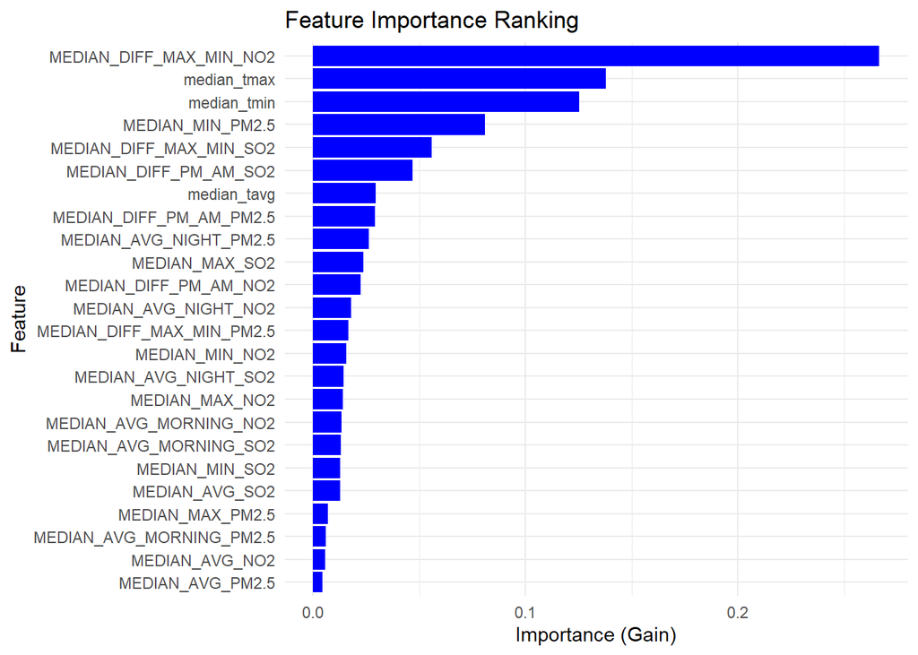

```r
# Specify the target and features
target <- "Lung_And_Bronchus"
features <- setdiff(names(data_XGB), target)

# Remove rows with missing values in the target feature
data_clean <- data_XGB %>% dplyr::filter(!is.na(Lung_And_Bronchus))

# Convert the cleaned data to a matrix format required by XGBoost
data_matrix <- xgb.DMatrix(data = as.matrix(data_clean[features]), label = data_clean[[target]])

# Set parameters for the XGBoost model
params <- list(
  objective = "reg:squarederror", # for regression
  eval_metric = "rmse",
  eta = 0.1,
  max_depth = 6
)

# Train the XGBoost model
xgb_model <- xgb.train(
  params = params,
  data = data_matrix,
  nrounds = 100,
  verbose = 0
)

# Get feature importance
importance <- xgb.importance(feature_names = features, model = xgb_model)

# Plot feature importance
ggplot(importance, aes(x = reorder(Feature, Gain), y = Gain)) +
  geom_bar(stat = "identity", fill = "blue") +
  coord_flip() +
  labs(title = "Feature Importance Ranking", x = "Feature", y = "Importance (Gain)") +
  theme_minimal()
```

- The most influential factor is MEDIAN_DIFF_MAX_MIN_NO2, representing the daily variability of NO2. High variability in NO2 levels may point to fluctuating pollution conditions that could have significant health impacts.
- Three temperature-related features (maximum, minimum, and average) rank among the top seven, suggesting that temperature fluctuations, which may affect pollutant dispersion and exposure, are correlated with lung cancer risks.
- The minimum value of PM2.5 is also crucial as it appears in the top 4
- The variability of sulfur dioxide (SO2) and nitrogen dioxide (NO2) is significant, indicating that fluctuations in pollution exposure, not just average levels, are important in correlating with lung cancer rates.

### Lasso

```r
# Establish connection
con <- dbConnect(odbc::odbc(),
                 Driver   = "ODBC Driver 17 for SQL Server",
                 Server   = "localhost",
                 Database = "research",
                 Port     = 1433,
                 Trusted_Connection = "Yes")


# Query the data
query <- "SELECT
[MEDIAN_MAX_NO2]
,[MEDIAN_MIN_NO2]
,[MEDIAN_AVG_NO2]
,[MEDIAN_MAX_SO2]
,[MEDIAN_MIN_SO2]
,[MEDIAN_AVG_SO2]
,[MEDIAN_MAX_PM2.5]
,[MEDIAN_MIN_PM2.5]
,[MEDIAN_AVG_PM2.5]
,[MEDIAN_AVG_MORNING_NO2]
,[MEDIAN_AVG_MORNING_SO2]
,[MEDIAN_AVG_MORNING_PM2.5]
,[MEDIAN_AVG_NIGHT_NO2]
,[MEDIAN_AVG_NIGHT_SO2]
,[MEDIAN_AVG_NIGHT_PM2.5]
,[MEDIAN_DIFF_MAX_MIN_NO2]
,[MEDIAN_DIFF_MAX_MIN_SO2]
,[MEDIAN_DIFF_MAX_MIN_PM2.5]
,[MEDIAN_DIFF_PM_AM_NO2]
,[MEDIAN_DIFF_PM_AM_SO2]
,[MEDIAN_DIFF_PM_AM_PM2.5]
,[median_tmin]
,[median_tmax]
,[median_tavg]
,[Lung_&_Bronchus]
FROM [dbo].[COMBINED]"

data_Mult_Imp <- dbGetQuery(con, query)

# Close the connection
dbDisconnect(con)

# Rename Columns
data_Mult_Imp <- data_Mult_Imp %>% rename(Lung_And_Bronchus = `Lung_&_Bronchus`)

# View the first few rows of the data
str(data_Mult_Imp)
```

```
## 'data.frame':    105766 obs. of  25 variables:
##  $ MEDIAN_MAX_NO2           : num  NA 29 27 25 35 30 27 NA 12 NA ...
##  $ MEDIAN_MIN_NO2           : num  NA 3 3 5 6 7 7 NA 1 NA ...
##  $ MEDIAN_AVG_NO2           : num  NA 10.3 10.1 11.9 18.9 ...
##  $ MEDIAN_MAX_SO2           : num  NA NA NA NA NA 0.4 NA NA NA NA ...
##  $ MEDIAN_MIN_SO2           : num  NA NA NA NA NA 0 NA NA NA NA ...
##  $ MEDIAN_AVG_SO2           : num  NA NA NA NA NA ...
##  $ MEDIAN_MAX_PM2.5         : num  11.9 NA NA NA NA ...
##  $ MEDIAN_MIN_PM2.5         : num  2.25 NA NA NA NA NA NA 1 NA -2 ...
##  $ MEDIAN_AVG_PM2.5         : num  6.9 NA NA NA NA ...
##  $ MEDIAN_AVG_MORNING_NO2   : num  NA 7.75 6 10.17 14.3 ...
##  $ MEDIAN_AVG_MORNING_SO2   : num  NA NA NA NA NA 0.22 NA NA NA NA ...
##  $ MEDIAN_AVG_MORNING_PM2.5 : num  5.87 NA NA NA NA ...
##  $ MEDIAN_AVG_NIGHT_NO2     : num  NA 12.5 13.8 12.1 22.1 ...
##  $ MEDIAN_AVG_NIGHT_SO2     : num  NA NA NA NA NA 0.1 NA NA NA NA ...
##  $ MEDIAN_AVG_NIGHT_PM2.5   : num  7.29 NA NA NA NA ...
##  $ MEDIAN_DIFF_MAX_MIN_NO2  : num  NA 22.5 24 20 30 24 20 NA 10 NA ...
##  $ MEDIAN_DIFF_MAX_MIN_SO2  : num  NA NA NA NA NA 0.3 NA NA NA NA ...
##  $ MEDIAN_DIFF_MAX_MIN_PM2.5: num  9.3 NA NA NA NA NA NA 7 NA 10 ...
##  $ MEDIAN_DIFF_PM_AM_NO2    : num  NA 3.73 6.04 2.47 5.43 ...
##  $ MEDIAN_DIFF_PM_AM_SO2    : num  NA NA NA NA NA ...
##  $ MEDIAN_DIFF_PM_AM_PM2.5  : num  1.05 NA NA NA NA ...
##  $ median_tmin              : num  4.61 4.61 4.61 6.65 6.65 ...
##  $ median_tmax              : num  17.2 17.2 17.2 19.2 19.2 ...
##  $ median_tavg              : num  10.8 10.8 10.8 12.9 12.9 ...
##  $ Lung_And_Bronchus        : num  61.2 61.2 61.2 39.5 39.5 39.5 39.5 39.5 39.5 39.5 ...
```

```r
# Perform multiple imputations
imputed_data <- mice(data_Mult_Imp, m = 10, method = 'pmm', maxit = 30, seed = 500)
# Check the summary of the imputed data
summary(imputed_data)
```

```r
# Initialize lists to store coefficients
lasso_models <- list()
selected_vars_list <- list()
lasso_coef_1se_matrix_list <- list()

# Initialize a matrix to store coefficients for all datasets
all_coefficients <- NULL

# Loop over each imputed dataset
for (i in 1:10) {
  # Extract the i-th imputed dataset
  dataset <- complete(imputed_data, i)

  # Define the response variable (y) and predictor matrix (x)
  y <- dataset$Lung_And_Bronchus
  x <- dataset[, -which(names(dataset) == "Lung_And_Bronchus")]

  # Scale the predictor matrix
  x_scaled <- scale(x)

  # Convert the scaled predictors to a matrix
  x_matrix <- as.matrix(x_scaled)

  # Fit LASSO model with cross-validation to find the optimal lambda
  cv_lasso <- cv.glmnet(x_matrix, y, alpha = 1)

  # Store CV Model for later plotting
  lasso_models[[i]] <- cv_lasso

  # Extract coefficients at lambda.1se
  lasso_coefs_1se <- coef(cv_lasso, s = "lambda.1se")

  # Convert to matrix and store coefficients
  lasso_coef_1se_matrix <- as.matrix(lasso_coefs_1se)
  lasso_coef_1se_matrix_list[[i]] <- lasso_coef_1se_matrix

  # Extract the coefficients (excluding intercept) and store in all_coefficients matrix
  all_coefficients <- cbind(all_coefficients, lasso_coef_1se_matrix[-1, ])

  # Extract variable names
  variable_names <- rownames(lasso_coef_1se_matrix)
  selected_vars <- variable_names[lasso_coef_1se_matrix != 0]

  # Store the selected variables
  selected_vars_list[[i]] <- selected_vars
}
```

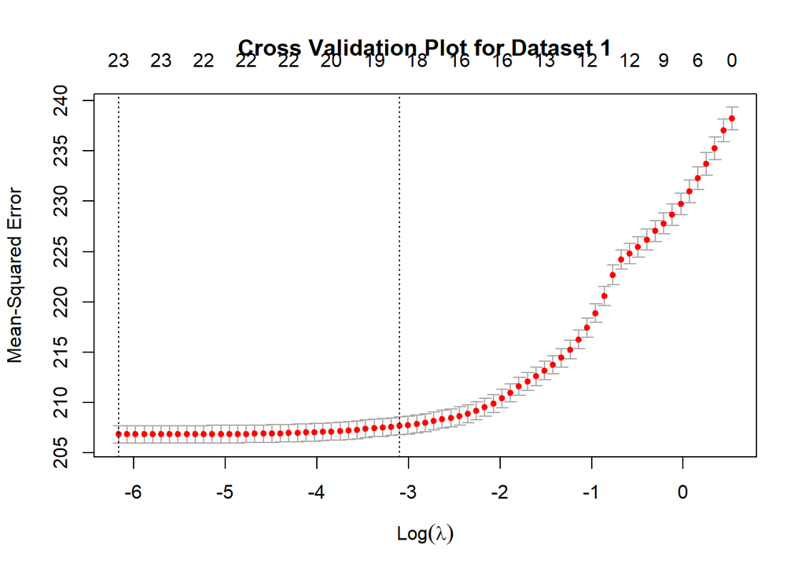

```r
# Plot CV Graph
plot(lasso_models[[1]], main = paste("Cross Validation Plot for Dataset 1"))
```

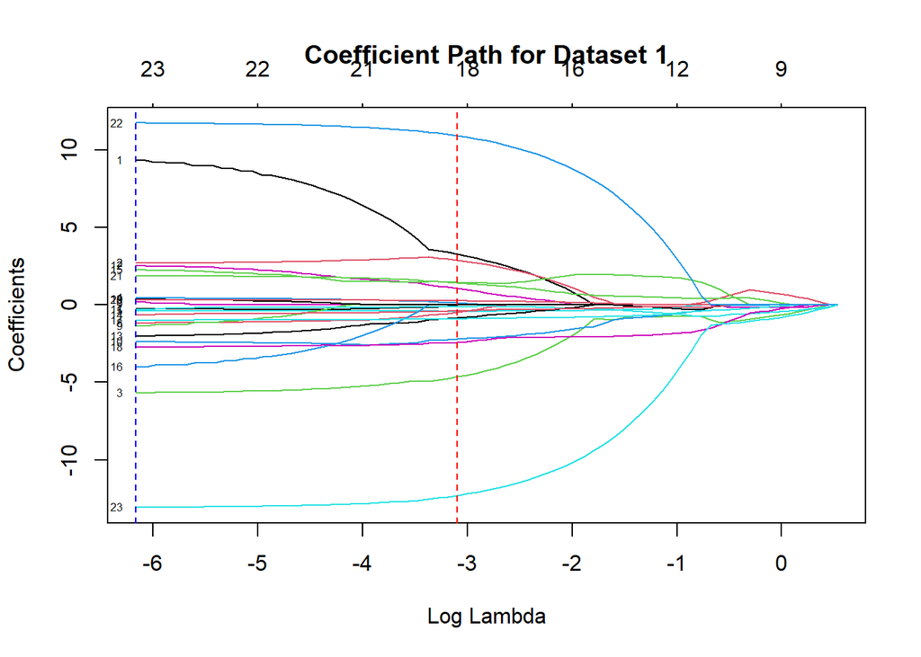

```r
# Plot Coefficient Path
plot(lasso_models[[1]]$glmnet.fit, xvar = "lambda", label = TRUE, main = paste("Coefficient Path for Dataset 1"))
abline(v = log(lasso_models[[1]]$lambda.min), col = "blue", lty = 2)
abline(v = log(lasso_models[[1]]$lambda.1se), col = "red", lty = 2)
```

```r
# Initialize a data frame to store lambda.min and lambda.1se for each dataset
lambda_values_df <- data.frame(Dataset = integer(), Lambda_Min = numeric(), Lambda_1SE = numeric())

# Loop through each LASSO model to extract lambda.min and lambda.1se
for (i in 1:10) {  # Adjust the range if you have more datasets
  lambda_min <- lasso_models[[i]]$lambda.min
  lambda_1se <- lasso_models[[i]]$lambda.1se

  # Add the values to the data frame
  lambda_values_df <- rbind(lambda_values_df,
                            data.frame(Dataset = i, Lambda_Min = lambda_min, Lambda_1SE = lambda_1se))
}

# Display the table with kable
kable(lambda_values_df, caption = "Lambda Min and 1SE Values for Each Dataset")
```

Lambda Min and 1SE Values for Each Dataset

| Dataset | Lambda_Min | Lambda_1SE |
| --- | --- | --- |
| 1 | 0.0021003 | 0.0452497 |
| 2 | 0.0030655 | 0.0455215 |
| 3 | 0.0030422 | 0.0311384 |
| 4 | 0.0011393 | 0.0390839 |
| 5 | 0.0021653 | 0.0561903 |
| 6 | 0.0025655 | 0.0665746 |
| 7 | 0.0023310 | 0.0502204 |
| 8 | 0.0015448 | 0.0303253 |
| 9 | 0.0028794 | 0.0427586 |
| 10 | 0.0026325 | 0.0567146 |

```r
# --- Aggregating Variable Importance Across Datasets ---

# Flatten the list of selected variables into a single vector
all_selected_vars <- unlist(selected_vars_list)

# Create a frequency table of how often each variable was selected
variable_importance <- table(all_selected_vars)

# Sort the variable importance in ascending order for plotting
sorted_variable_importance <- sort(variable_importance, decreasing = FALSE)

# --- Creating a Data Frame for Coefficients ---

# Combine coefficients from all datasets into a data frame
coefficients_df <- data.frame(all_coefficients)

# Assign row names (variable names) and column names (dataset identifiers)
rownames(coefficients_df) <- rownames(lasso_coef_1se_matrix)[-1]
colnames(coefficients_df) <- paste("Dataset", 1:10, sep = " ")

# Calculate the average of the coefficients across datasets and add as a new column
coefficients_df$Average <- rowMeans(coefficients_df)

# Add the frequency of non-zero coefficients (from variable importance) as a new column
coefficients_df$Nonzero_Count <- sorted_variable_importance[rownames(coefficients_df)]

# Optionally display the table in a more formatted way using kable
kable(coefficients_df, caption = "Table of Coefficients Across Imputed Datasets with Averages")
```

Table of Coefficients Across Imputed Datasets with Averages

|  | Dataset 1 | Dataset 2 | Dataset 3 | Dataset 4 | Dataset 5 | Dataset 6 | Dataset 7 | Dataset 8 | Dataset 9 | Dataset 10 | Average | Nonzero_Count |
| --- | --- | --- | --- | --- | --- | --- | --- | --- | --- | --- | --- | --- |
| MEDIAN_MAX_NO2 | 3.2761002 | 3.5770427 | 4.1751086 | 5.0118632 | 2.9445604 | 3.1151430 | 3.7735904 | 4.0738427 | 3.7373850 | 2.7678825 | 3.6452519 | 10 |
| MEDIAN_MIN_NO2 | 2.8801909 | 3.0114018 | 3.0154527 | 2.7633616 | 2.7313397 | 2.6711491 | 2.5147806 | 2.9290658 | 3.2372069 | 2.3611221 | 2.8115071 | 10 |
| MEDIAN_AVG_NO2 | -4.6434178 | -5.2099528 | -5.0684873 | -5.9244019 | -3.9013159 | -5.1124909 | -5.7369027 | -4.8951256 | -5.7359109 | -4.5335074 | -5.0761513 | 10 |
| MEDIAN_MAX_SO2 | 0.1228247 | 0.0000000 | 0.0000000 | 0.0000000 | 0.0000000 | 0.0000000 | 0.0000000 | 0.0533909 | -0.0235397 | 0.0000000 | 0.0152676 | 3 |
| MEDIAN_MIN_SO2 | -0.4116596 | -0.5177063 | -0.5854108 | -0.6445786 | -0.4878809 | -0.5776835 | -0.6249998 | -0.6883407 | -0.5982280 | -0.4798969 | -0.5616385 | 10 |
| MEDIAN_AVG_SO2 | 0.0000000 | -0.0038481 | -0.1041567 | 0.0000000 | -0.2367161 | 0.0000000 | -0.1873816 | -0.0495817 | -0.1449602 | 0.0000000 | -0.0726644 | 6 |
| MEDIAN_MAX_PM2.5 | -0.0007829 | -0.5485382 | -1.0281709 | -0.6393881 | -0.2191564 | -0.8229571 | -0.4364333 | -0.8891433 | -0.3604916 | -0.7125575 | -0.5657619 | 10 |
| MEDIAN_MIN_PM2.5 | -0.4790259 | -0.2064487 | -0.4287649 | -0.1896223 | -0.2301077 | -0.2792444 | -0.7726785 | -0.6105137 | -0.1424543 | -0.1438425 | -0.3482703 | 10 |
| MEDIAN_AVG_PM2.5 | 0.0000000 | 0.0000000 | 0.0000000 | 0.0000000 | 0.0000000 | 0.0000000 | 0.0000000 | 0.0000000 | 0.0000000 | 0.0000000 | 0.0000000 | NA |
| MEDIAN_AVG_MORNING_NO2 | -2.2102587 | -1.8278511 | -2.1731392 | -2.0298030 | -2.3316313 | -1.4458586 | -1.2914908 | -2.2934019 | -1.9413088 | -1.4117234 | -1.8956467 | 10 |
| MEDIAN_AVG_MORNING_SO2 | -0.1164284 | 0.0000000 | 0.0000000 | -0.0637665 | -0.0386772 | -0.1553291 | -0.0049958 | 0.0000000 | 0.0000000 | -0.1689460 | -0.0548143 | 6 |
| MEDIAN_AVG_MORNING_PM2.5 | 1.0556092 | 0.4069612 | 1.7138264 | 1.1299580 | 0.6295122 | 0.8358408 | 1.2348332 | 1.3283657 | 0.6561464 | 1.1049401 | 1.0095993 | 10 |
| MEDIAN_AVG_NIGHT_NO2 | -0.8294051 | -0.9330902 | -0.9252079 | -0.3400811 | -1.0367857 | -0.7004193 | -0.6535936 | -1.2855669 | -0.7052138 | -0.6508075 | -0.8060171 | 10 |
| MEDIAN_AVG_NIGHT_SO2 | -0.3931527 | -0.2934584 | -0.1425211 | -0.1915536 | 0.0000000 | -0.1309845 | 0.0000000 | -0.2069074 | -0.1006264 | -0.1304979 | -0.1589702 | 8 |
| MEDIAN_AVG_NIGHT_PM2.5 | 1.4513124 | 2.1564992 | 1.4068544 | 1.3922601 | 1.7273707 | 2.0053632 | 1.8781581 | 2.0851649 | 1.8050743 | 1.5369801 | 1.7445037 | 10 |
| MEDIAN_DIFF_MAX_MIN_NO2 | 0.0000000 | 0.0000000 | -0.5230443 | -1.1393386 | 0.0000000 | 0.0000000 | 0.0000000 | -0.0014490 | 0.0000000 | 0.0000000 | -0.1663832 | 3 |
| MEDIAN_DIFF_MAX_MIN_SO2 | -0.8976113 | -1.0220656 | -0.9637961 | -1.0893955 | -0.9937065 | -1.0108185 | -0.9544928 | -1.1466709 | -0.9722280 | -1.0694406 | -1.0120226 | 10 |
| MEDIAN_DIFF_MAX_MIN_PM2.5 | -2.4366077 | -1.8409687 | -1.8548084 | -1.7557229 | -2.0497543 | -1.7446653 | -2.4216568 | -2.0857691 | -2.0060749 | -1.7826901 | -1.9978718 | 10 |
| MEDIAN_DIFF_PM_AM_NO2 | 0.0000000 | 0.0000000 | 0.0773704 | 0.0000000 | 0.0000000 | 0.0000000 | 0.0000000 | 0.0000000 | 0.0000000 | 0.0000000 | 0.0077370 | 1 |
| MEDIAN_DIFF_PM_AM_SO2 | 0.2597605 | 0.2600249 | 0.2404287 | 0.1326697 | 0.2332946 | 0.1178587 | 0.1453253 | 0.2478885 | 0.2503669 | 0.1953598 | 0.2082978 | 10 |
| MEDIAN_DIFF_PM_AM_PM2.5 | 1.4270288 | 1.0302964 | 1.6544148 | 1.5478240 | 1.1852615 | 1.2049396 | 1.5294908 | 1.4587894 | 1.2981449 | 1.3869733 | 1.3723163 | 10 |
| median_tmin | 10.8968029 | 10.8908360 | 11.2413247 | 11.1671786 | 10.6876379 | 10.3254395 | 10.8746883 | 11.1480048 | 10.8940945 | 10.5384101 | 10.8664417 | 10 |
| median_tmax | -12.2848099 | -12.2586306 | -12.6473411 | -12.5541070 | -12.0489754 | -11.7110566 | -12.2124950 | -12.5813168 | -12.2552077 | -11.9583121 | -12.2512252 | 10 |
| median_tavg | 0.0000000 | 0.0000000 | 0.0000000 | 0.0000000 | 0.0000000 | 0.0000000 | 0.0000000 | 0.0000000 | 0.0000000 | 0.0000000 | 0.0000000 | NA |

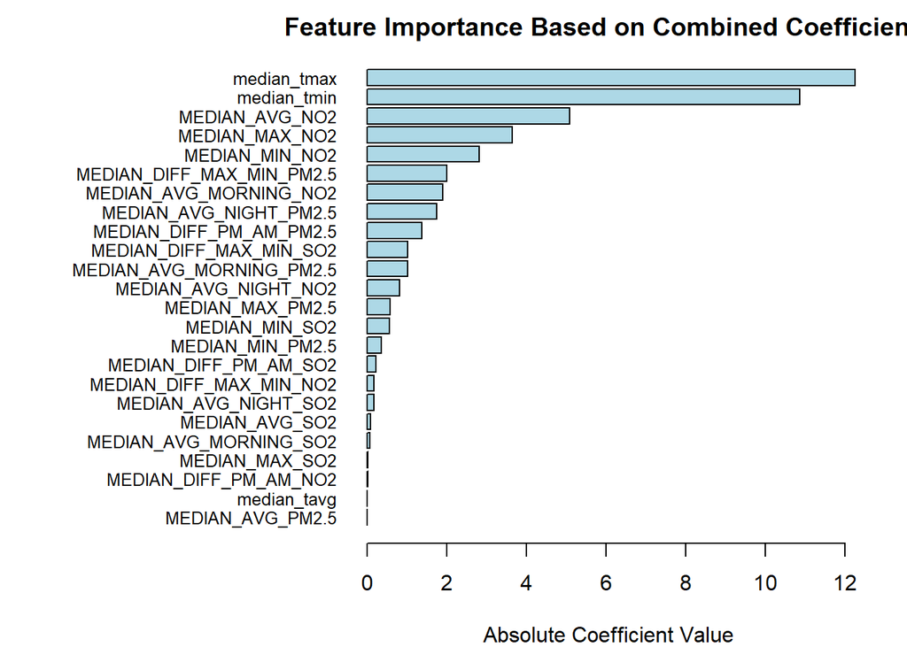

```r
# --- Combining and Ordering Coefficients Across Datasets ---

# Combine coefficients across all datasets by averaging them
combined_lasso_coef_1se_matrix <- Reduce("+", lasso_coef_1se_matrix_list) / length(lasso_coef_1se_matrix_list)

# Remove the intercept row from the combined coefficients
combined_lasso_coef_1se_matrix <- combined_lasso_coef_1se_matrix[-1, , drop = FALSE]

# Order variables by the absolute magnitude of their averaged coefficients (ascending order)
ordered_combined_coef <- sort(abs(combined_lasso_coef_1se_matrix[, 1]), decreasing = FALSE)

# --- Plotting Feature Importance Based on Combined Coefficients ---

# Adjust margins for better label visibility
par(mar = c(4, 14, 2, 2))

# Create a horizontal barplot for feature importance based on combined coefficients
barplot(ordered_combined_coef,
        horiz = TRUE,
        las = 1,
        col = "lightblue",
        main = "Feature Importance Based on Combined Coefficients",
        xlab = "Absolute Coefficient Value",
        cex.names = 0.8)
```

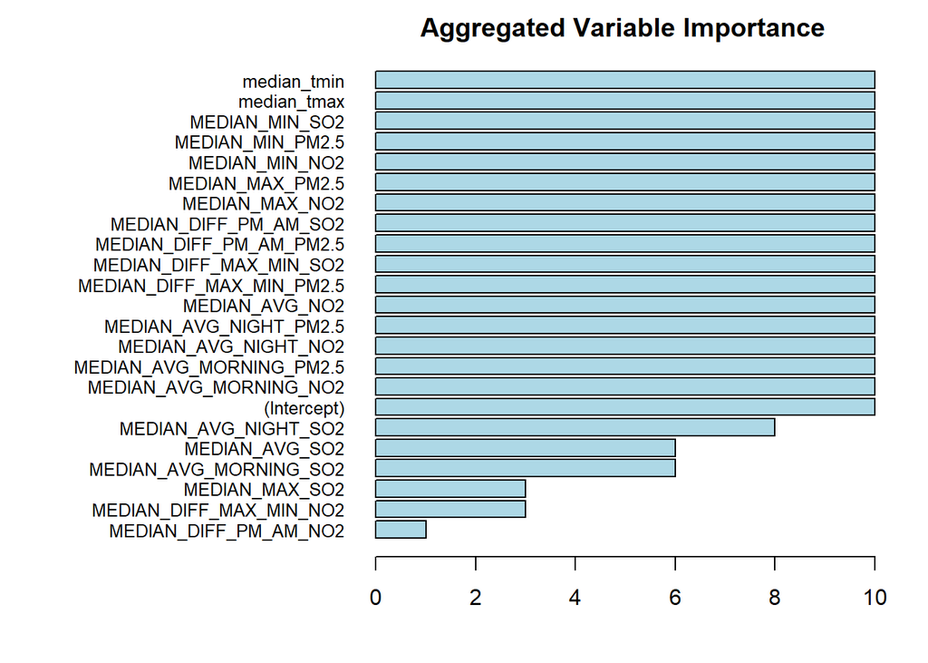

```r
# --- Plotting Aggregated Variable Importance ---

# Create a horizontal barplot for aggregated variable importance
barplot(sorted_variable_importance,
        horiz = TRUE,
        las = 1,
        col = "lightblue",
        main = "Aggregated Variable Importance",
        cex.names = 0.8)
```

# Discussion

CONCERNS

- Considering that cancer takes time to develop, the lag between air pollution exposure and cancer diagnosis needs to be taken into account. What is an appropriate time difference between the air pollution data and cancer data to accurately measure the impact of pollution on cancer development? In the dataset, pollution and weather data was taken from 2010 to 2019, while cancer was taken from 2016 to 2020. This may be a concern as cancer could develop over several decades instead of several years.
- Data recorded by mip code might be more accurate since it’s a smaller area, but cancer data from the sources only reports by county.
- Few sites have all three NO2, PM2.5 and SO2 at the same time, meaning many rows were removed because they contained at least one null values. This is a big concern since datasets used to run PCA and KMeans only had 6k rows out of the total 100k rows from the original dataset.
- This research focuses solely on air pollution and its effect. Although there are many other factors that cause lung cancer, including genetics, healthcare access, and lifestyle habits such as smoking, it is not covered in this research paper

RESULTS The amount of pollution isn’t the only factor in air pollution. We also considered temperature and variability Temperature may be related to outdoor activity and may affect the pollutant exposure and dispersion. Daily variance may be related to human related pollution

# References

Gap statistic: https://hastie.su.domains/Papers/gap.pdf WHO: https://www.who.int/health-topics/air-pollution#tab=tab_1